# Lab 14 - Support Vector Machines

##### d) Plot SVMs created with linear and polynomial kernels. Compare with previous plot.

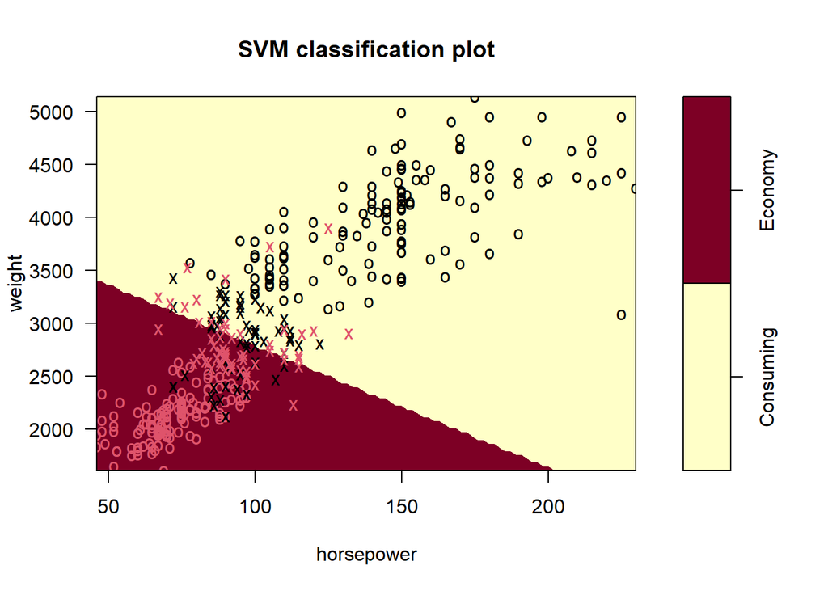

```r
svm(eco ~ weight + horsepower, data = Auto2, kernel = "linear") |> plot(Auto2, grid = 100)
```

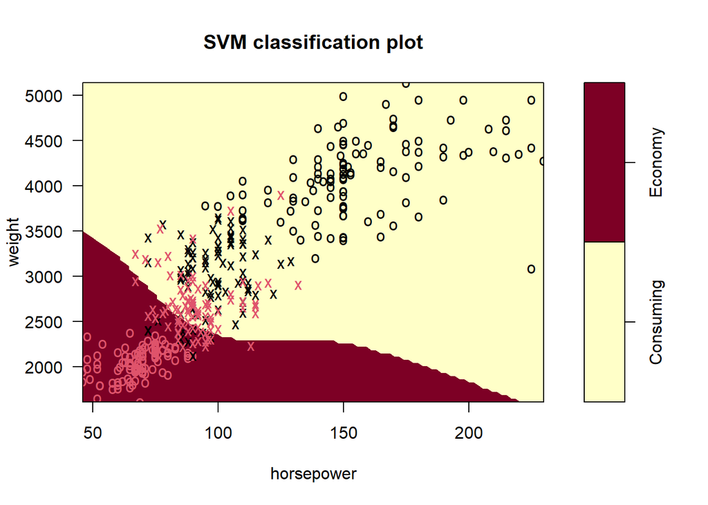

```r
svm(eco ~ weight + horsepower, data = Auto2, kernel = "polynomial") |> plot(Auto2, grid = 100)
```

As expected, the margins are different then the curved margin found with the `radial` kernel. In the linear kernel, it seems that more cars are tend to be classified as `Economy` than before. While with the polynomial kernel, it tries to classify more cars as `Consuming`.

##### e) Optimize the SVM using tune() (which invokes tune.svm).

- Try costs 0.01, 0.1, 1, 10, 100, 1000.
- Try linear, polynomial, sigmoid, and radial kernels.
- Look at the top three models in terms of error.
- Plot the error by cost, colored by kernel.

```r
set.seed(my_seed <- 1234)
S_tuned <- tune(svm, eco ~ weight + horsepower, data = Auto2,
                ranges = list(cost = 10^seq(-2, 3),
                              kernel = c("linear", "polynomial", "sigmoid", "radial")))
summary(S_tuned)
```

```
Parameter tuning of 'svm':

- sampling method: 10-fold cross validation

- best parameters:
 cost kernel
 1000 radial

- best performance: 0.1096154

- Detailed performance results:
    cost     kernel     error dispersion
1  1e-02     linear 0.1376923 0.06926822
2  1e-01     linear 0.1121154 0.03803233
3  1e+00     linear 0.1247436 0.03961149
4  1e+01     linear 0.1272436 0.04980718
5  1e+02     linear 0.1246795 0.05040856
6  1e+03     linear 0.1246795 0.05040856
7  1e-02 polynomial 0.2653846 0.10583116
8  1e-01 polynomial 0.1757692 0.10640674
9  1e+00 polynomial 0.1757692 0.07125919
10 1e+01 polynomial 0.1580128 0.04527823
11 1e+02 polynomial 0.1529487 0.04599053
12 1e+03 polynomial 0.1554487 0.04656674
13 1e-02    sigmoid 0.1530128 0.07426316
14 1e-01    sigmoid 0.1171795 0.04649761
15 1e+00    sigmoid 0.1144872 0.04416435
16 1e+01    sigmoid 0.1451282 0.04376974
17 1e+02    sigmoid 0.1553205 0.03908102
18 1e+03    sigmoid 0.1578846 0.03980793
19 1e-02     radial 0.1350641 0.05626604
20 1e-01     radial 0.1171795 0.03375365
21 1e+00     radial 0.1221795 0.04682189
22 1e+01     radial 0.1146795 0.03818090
23 1e+02     radial 0.1146795 0.03818090
24 1e+03     radial 0.1096154 0.03800777
```

```r
arrange(S_tuned$performances, error)[1:3,]
```

```
   cost  kernel     error dispersion
1 1e+03  radial 0.1096154 0.03800777
2 1e-01  linear 0.1121154 0.03803233
3 1e+00 sigmoid 0.1144872 0.04416435
```

```r
S_tuned$best.model
```

```
Call:
best.tune(METHOD = svm, train.x = eco ~ weight + horsepower, data = Auto2,
    ranges = list(cost = 10^seq(-2, 3), kernel = c("linear", "polynomial",
        "sigmoid", "radial")))


Parameters:
   SVM-Type:  C-classification
 SVM-Kernel:  radial
       cost:  1000

Number of Support Vectors:  98
```

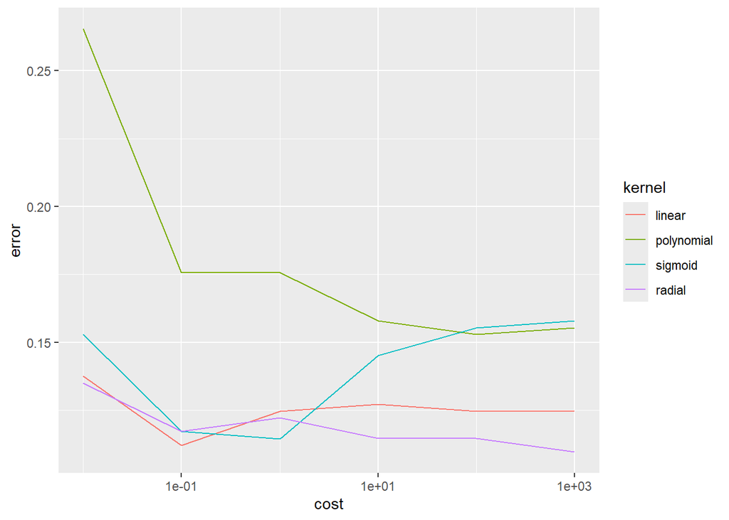

```r
S_tuned$performances |>
  ggplot(aes(x = cost, y = error, colour = kernel)) +
  geom_line() +
  scale_x_log10()
```

##### f) Use the validation set method to estimate the classification rate using the parameters from two best models. Use a 50% split with seed 1234.

```r
set.seed(my_seed)
n <-  nrow(Auto2)
Z = sample(n,n/2)

S_trainr = svm(eco ~ weight + horsepower, Auto2[Z,], cost = 1000,
               kernel = "radial")
Yhatr <- predict( S_trainr, Auto2[-Z,])
table(Yhatr, Auto2$eco[-Z])
```

```
Yhatr       Consuming Economy
  Consuming        84       5
  Economy          18      89
```

```r
mean(Yhatr == Auto2$eco[-Z]) |> round(2)
```

```
[1] 0.88
```

```r
S_trainl = svm(eco ~ weight + horsepower, Auto2[Z,], cost = 0.1,
               kernel = "linear")
Yhatl <- predict( S_trainl, Auto2[-Z,])
table(Yhatl, Auto2$eco[-Z])
```

```
Yhatl       Consuming Economy
  Consuming        73       4
  Economy          29      90
```

```r
mean(Yhatl == Auto2$eco[-Z]) |> round(2)
```

```
[1] 0.83
```

The `radial` kernel achieved higher classification rate of 88% compared to the linear kernel with classification rate of 83%.

In conclusion, the results confirm what we observed in the tuning plot: Radial kernel is the optimal choice for this classification task.

##### g) Create a new data frame with four levels for `eco` as below.

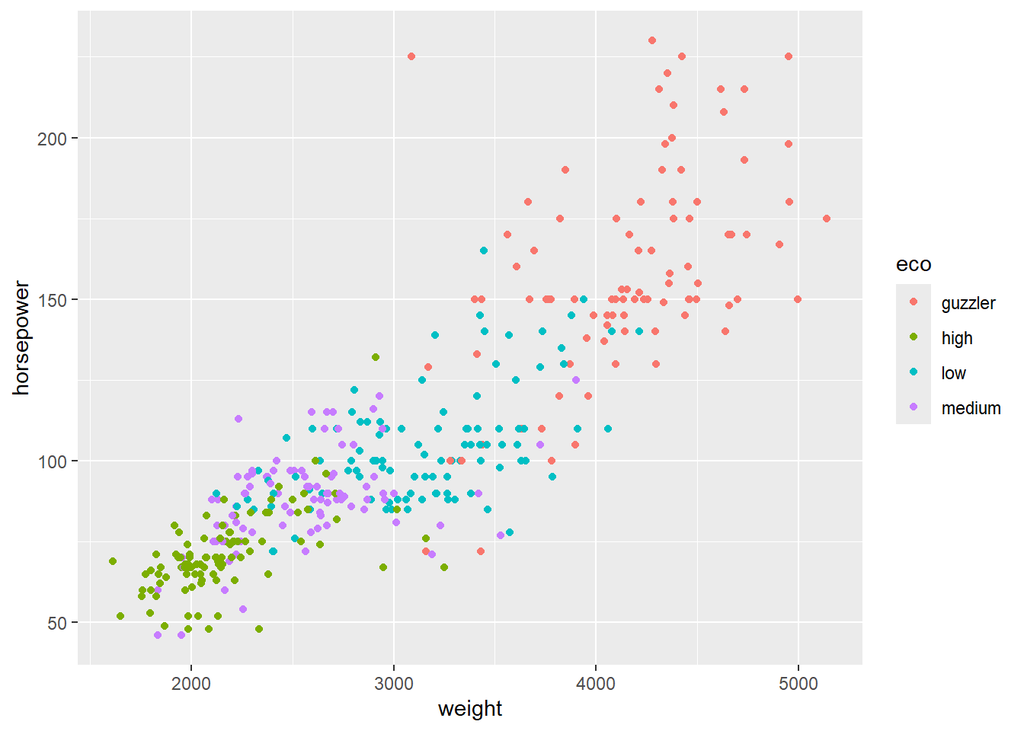

```r
Auto |>
mutate(eco = as.factor(case_when(
    mpg < 17 ~ "guzzler",
    mpg >= 17 & mpg <22.75 ~ "low",
    mpg >= 22.75 &  mpg < 29 ~ "medium",
    .default = "high")),
    .before = cylinders) |>
  select(eco, weight, horsepower) ->
  Auto3
ggplot(Auto3, aes(x = weight, y = horsepower, color = eco)) +
  geom_point()
```

- Use `svm()` with `tune()` to create an optimal model to predict the multiple classes based on 10-fold cross validation on the training set with the previous costs and kernels.

```r
set.seed(my_seed)
S_tuned <- tune(svm, eco ~ weight + horsepower, data = Auto3[Z,],
                ranges = list(cost = 10^seq(-2, 3),
                kernel = c("linear", "polynomial", "sigmoid", "radial"))
                )
arrange(S_tuned$performances, error)[1:3,]
```

```
  cost     kernel     error dispersion
1 1000 polynomial 0.3365789  0.1009454
2  100     linear 0.3378947  0.1233210
3 1000     linear 0.3378947  0.1233210
```

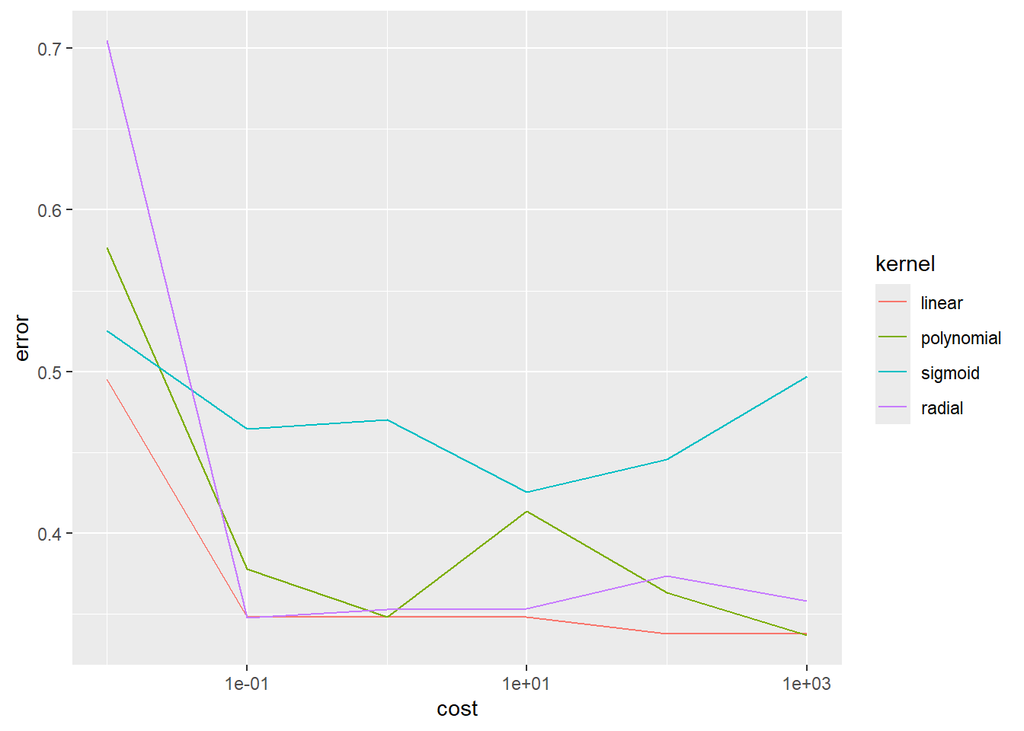

```r
S_tuned$performances |>
  ggplot(aes(x = cost, y = error, colour = kernel)) +
  geom_line() +
  scale_x_log10()
```

- Calculate the classification rate based on the optimal model with the test data.

```r
S_trainp = svm(eco ~ weight + horsepower, Auto3[Z,], cost = 1000,
               kernel = "polynomial")
Yhatp <- predict(S_trainp, Auto3[-Z,])
table(Yhatp, Auto3$eco[-Z])
```

```
Yhatp     guzzler high low medium
  guzzler      34    0   4      0
  high          0   41   0      4
  low           7    1  37      7
  medium        1   13  19     28
```

```r
mean(Yhatp == Auto3$eco[-Z]) |> round(2)
```

```
[1] 0.71
```

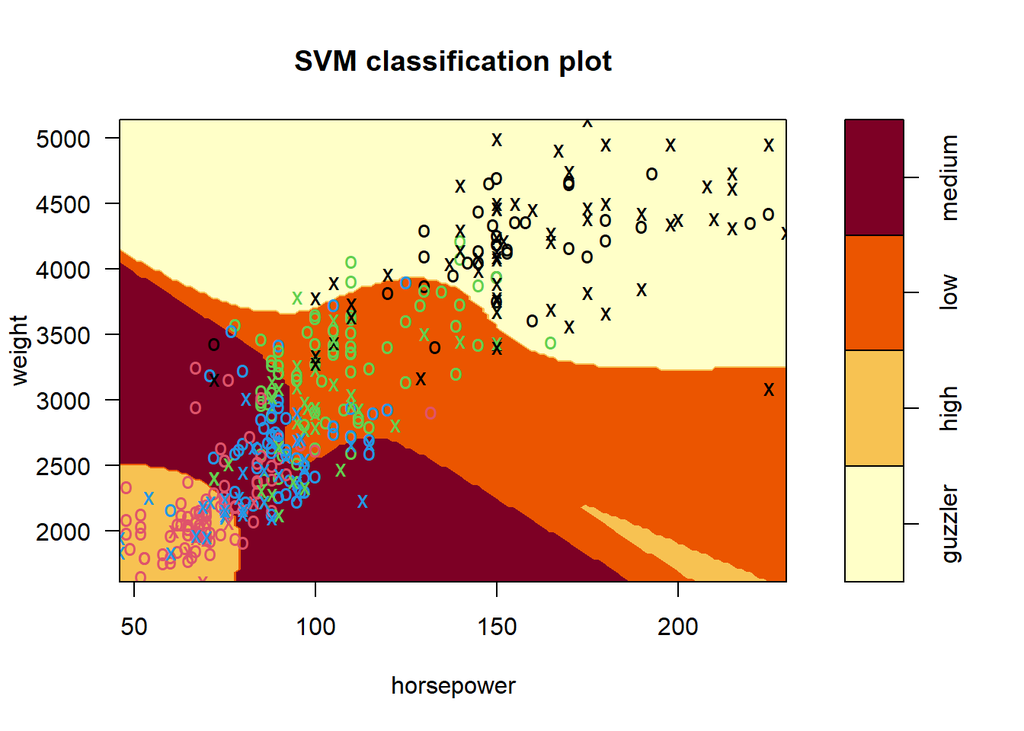

```r
plot(S_trainp, Auto3, grid = 150)
```

```r
S_trainl4 = svm(eco ~ weight + horsepower, Auto3[Z,], cost = 100,
               kernel = "linear")
Yhatl4 <- predict(S_trainl4, Auto3[-Z,])
table(Yhatl4, Auto3$eco[-Z])
```

```
Yhatl4    guzzler high low medium
  guzzler      36    0   4      0
  high          0   46   2      5
  low           5    1  41      7
  medium        1    8  13     27
```

```r
mean(Yhatl4 == Auto3$eco[-Z]) |> round(2)
```

```
[1] 0.77
```

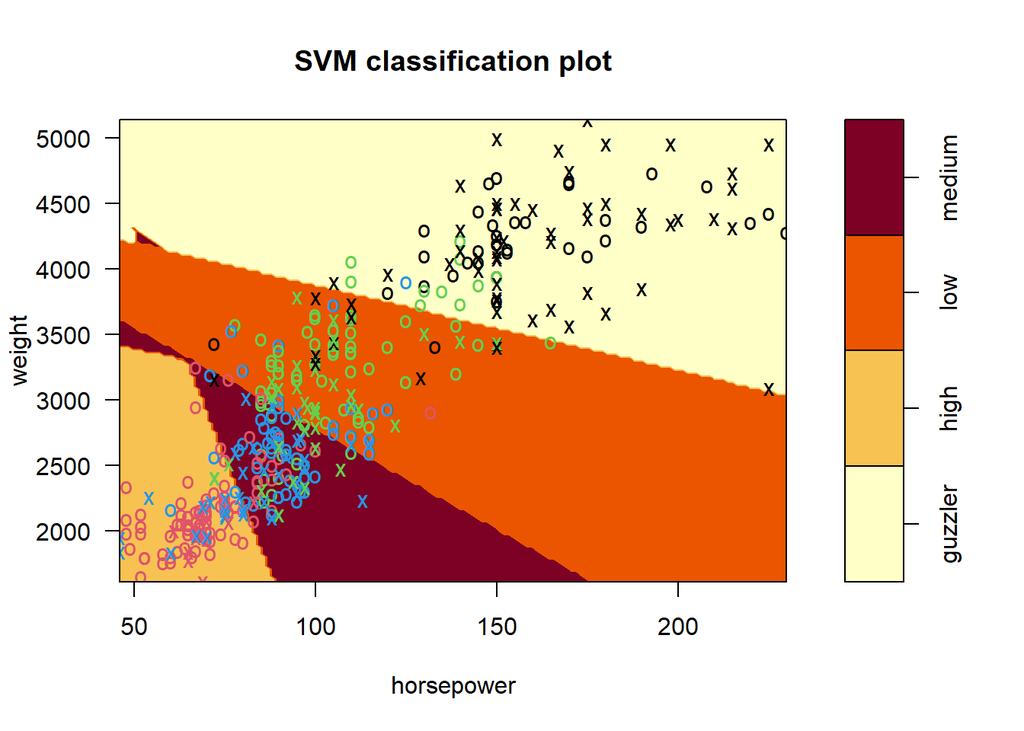

```r
plot(S_trainl4, Auto3, grid = 150)
```